# Notebook

```python
%load_ext rpy2.ipython
```

## 4.6.1 The Stock Market Data

```python
%%R
library(ISLR)

dim(Smarket)
```

```
[1] 1250    9
```

```python
names(Smarket)
```

[1] "Year" "Lag1" "Lag2" "Lag3" "Lag4" "Lag5" "Volume" "Today"  
[9] "Direction"

```python
summary(Smarket)
```

```
      Year           Lag1                Lag2                Lag3                Lag4
 Min.   :2001   Min.   :-4.922000   Min.   :-4.922000   Min.   :-4.922000   Min.   :-4.922000
 1st Qu.:2002   1st Qu.:-0.639500   1st Qu.:-0.639500   1st Qu.:-0.640000   1st Qu.:-0.640000
 Median :2003   Median : 0.039000   Median : 0.039000   Median : 0.038500   Median : 0.038500
 Mean   :2003   Mean   : 0.003834   Mean   : 0.003919   Mean   : 0.001716   Mean   : 0.001636
 3rd Qu.:2004   3rd Qu.: 0.596750   3rd Qu.: 0.596750   3rd Qu.: 0.596750   3rd Qu.: 0.596750
 Max.   :2005   Max.   : 5.733000   Max.   : 5.733000   Max.   : 5.733000   Max.   : 5.733000
      Lag5              Volume           Today           Direction
 Min.   :-4.92200   Min.   :0.3561   Min.   :-4.922000   Down:602
 1st Qu.:-0.64000   1st Qu.:1.2574   1st Qu.:-0.639500   Up  :648
 Median : 0.03850   Median :1.4229   Median : 0.038500
 Mean   : 0.00561   Mean   :1.4783   Mean   : 0.003138
 3rd Qu.: 0.59700   3rd Qu.:1.6417   3rd Qu.: 0.596750
 Max.   : 5.73300   Max.   :3.1525   Max.   : 5.733000
```

```python
cor(Smarket[,-9])  # you cannot use cor( ) for qualitative variable
```

we can see little correlation between today's return and previous day's return

```
             Year         Lag1         Lag2         Lag3         Lag4         Lag5      Volume
Year   1.00000000  0.029699649  0.030596422  0.033194581  0.035688718  0.029787995  0.53900647
Lag1   0.02969965  1.000000000 -0.026294328 -0.010803402 -0.002985911 -0.005674606  0.04090991
Lag2   0.03059642 -0.026294328  1.000000000 -0.025896670 -0.010853533 -0.003557949 -0.04338321
Lag3   0.03319458 -0.010803402 -0.025896670  1.000000000 -0.024051036 -0.018808338 -0.04182369
Lag4   0.03568872 -0.002985911 -0.010853533 -0.024051036  1.000000000 -0.027083641 -0.04841425
Lag5   0.02978799 -0.005674606 -0.003557949 -0.018808338 -0.027083641  1.000000000 -0.02200231
Volume 0.53900647  0.040909908 -0.043383215 -0.041823686 -0.048414246 -0.022002315  1.00000000
Today  0.03009523 -0.026155045 -0.010250033 -0.002447647 -0.006899527 -0.034860083  0.01459182
              Today
Year    0.030095229
Lag1   -0.026155045
Lag2   -0.010250033
Lag3   -0.002447647
Lag4   -0.006899527
Lag5   -0.034860083
Volume  0.014591823
Today   1.000000000
```

## 4.6.2 Logistic Regression

We want to predict Direction by using Lag1~5 and Volume (the number of shares traded on the previous day)

```python
%%R
attach(Smarket)
glm.fit <- glm(Direction ~ Lag1 + Lag2 + Lag3 + Lag4 + Lag5 + Volume, data=Smarket, family=binomial)
```

```python
summary(glm.fit)
```

```
Call:
glm(formula = Direction ~ Lag1 + Lag2 + Lag3 + Lag4 + Lag5 +
    Volume, family = binomial, data = Smarket)

Deviance Residuals:
   Min      1Q  Median      3Q     Max
-1.446  -1.203   1.065   1.145   1.326

Coefficients:
             Estimate Std. Error z value Pr(>|z|)
(Intercept) -0.126000   0.240736  -0.523    0.601
Lag1        -0.073074   0.050167  -1.457    0.145
Lag2        -0.042301   0.050086  -0.845    0.398
Lag3         0.011085   0.049939   0.222    0.824
Lag4         0.009359   0.049974   0.187    0.851
Lag5         0.010313   0.049511   0.208    0.835
Volume       0.135441   0.158360   0.855    0.392

(Dispersion parameter for binomial family taken to be 1)

    Null deviance: 1731.2  on 1249  degrees of freedom
Residual deviance: 1727.6  on 1243  degrees of freedom
AIC: 1741.6

Number of Fisher Scoring iterations: 3
```

The predit( ) function can be used to predict the probability that the market will go up.  
type="response" tells R to output probabilities of the form P(Y=1 | X).  
If no dataset is supplied to the predict( ) function, then the probabilities are computed for the training data that was used to fit the logistic regression model.

```python
%%R
glm.probs = predict(glm.fit, type="response")
```

```python
glm.probs[1:10]
```

```
        1         2         3         4         5         6         7         8         9
0.5070841 0.4814679 0.4811388 0.5152224 0.5107812 0.5069565 0.4926509 0.5092292 0.5176135
       10
0.4888378
```

```python
%%R
contrasts(Direction)
```

```
     Up
Down  0
Up    1
```

Now, let's see whether the market will go up or down on a particular day.

```python
%%R
glm.pred = rep("Down", 1250)
glm.pred[glm.probs > .5]="Up"
```

```python
> glm.pred[1:15] # we made a vector for labels
```

```
 [1] "Up"   "Down" "Down" "Up"   "Up"   "Up"   "Down" "Up"   "Up"   "Down" "Down" "Up"   "Up"
[14] "Down" "Down"
```

```python
table(glm.pred, Direction)
```

```
        Direction
glm.pred Down  Up
    Down  145 141
    Up    457 507
```

```python
%%R
mean(glm.pred==Direction)
```

```
[1] 0.5216
```

#### Until now, we test the model with the training data, which means the actual performance with new dataset is worse. So, we fit the model using the part of the data, and then examine how well it predicts the helt out data.

```python
%%R
train = (Year < 2005) # a (Boolean) vector corresponding to the observations from 2001 through 2004
Smarket.2005 = Smarket[!train,] # "!" can be used to reverse all the elements of a Boolean vactor i.e. TRUE -> F, FALSE -> T
        # Smarket[train,] will return observations corresponded only to the dates before 2005
Direction.2005 = Direction[!train]
```

```python
%%R
summary(train)
```

```
   Mode   FALSE    TRUE    NA's
logical     252     998       0
```

```python
%%R
head(Smarket.2005)
```

```
     Year   Lag1   Lag2   Lag3   Lag4   Lag5 Volume  Today Direction
999  2005 -0.134  0.008 -0.007  0.715 -0.431 0.7869 -0.812      Down
1000 2005 -0.812 -0.134  0.008 -0.007  0.715 1.5108 -1.167      Down
1001 2005 -1.167 -0.812 -0.134  0.008 -0.007 1.7210 -0.363      Down
1002 2005 -0.363 -1.167 -0.812 -0.134  0.008 1.7389  0.351        Up
1003 2005  0.351 -0.363 -1.167 -0.812 -0.134 1.5691 -0.143      Down
1004 2005 -0.143  0.351 -0.363 -1.167 -0.812 1.4779  0.342        Up
```

```python
%%R
head(Direction.2005)
```

```
[1] Down Down Down Up   Down Up
Levels: Down Up
```

```python
%%R
glm.fit <- glm(Direction ~ Lag1 + Lag2 + Lag3 + Lag4 + Lag5 + Volume, data=Smarket, family=binomial, subset=train)
glm.probs <- predict(glm.fit, Smarket.2005, type="response")
        # we have trained and tested our model on two completely separate datasets
```

```python
%%R
glm.pred = rep("Down", 252)
glm.pred[glm.probs > .5] = "Up"
table(glm.pred, Direction.2005)
```

```
        Direction.2005
glm.pred Down Up
    Down   77 97
    Up     34 44
```

```python
%%R
mean(glm.pred==Direction.2005)
```

```
[1] 0.4801587
```

```python
%%R
mean(glm.pred!=Direction.2005)  # calculate test error rate
```

```
[1] 0.5198413
```

## 4.6.3 Linear Discriminant Analysis

```python
%%R
library(MASS)
lda.fit <- lda(Direction ~ Lag1 + Lag2, data=Smarket, subset=train)
```

```python
lda.fit
```

Group means: the average of each predictor within each class. These suggests that there is a tendency for previous 2 day's returns to be negative on days when market increases.

```
Call:
lda(Direction ~ Lag1 + Lag2, data = Smarket, subset = train)

Prior probabilities of groups:
    Down       Up
0.491984 0.508016

Group means:
            Lag1        Lag2
Down  0.04279022  0.03389409
Up   -0.03954635 -0.03132544

Coefficients of linear discriminants:
            LD1
Lag1 -0.6420190
Lag2 -0.5135293
```

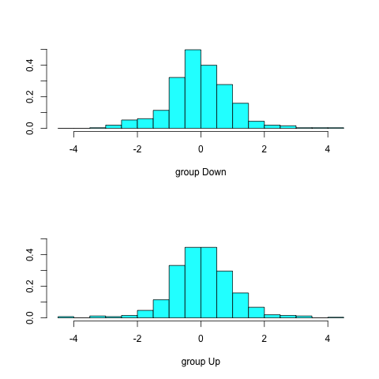

```python
%%R
plot(lda.fit) # plots of the linear discriminants
```

```python
%%R
lda.pred <- predict(lda.fit, Smarket.2005)
names(lda.pred)
```

```
[1] "class"     "posterior" "x"
```

```python
%%R
lda.class = lda.pred$class
table(lda.class, Direction.2005)
```

```
         Direction.2005
lda.class Down  Up
     Down   35  35
     Up     76 106
```

```python
%%R
mean(lda.class==Direction.2005)
```

```
[1] 0.5595238
```

```python
%%R
lda.pred$posterior[1:20, 1]
lda.class[1:20]
# we can know that the probability output by the model corresponds to the probability that the market will decrease
```

```
      999      1000      1001      1002      1003      1004      1005      1006      1007
0.4901792 0.4792185 0.4668185 0.4740011 0.4927877 0.4938562 0.4951016 0.4872861 0.4907013
     1008      1009      1010      1011      1012      1013      1014      1015      1016
0.4844026 0.4906963 0.5119988 0.4895152 0.4706761 0.4744593 0.4799583 0.4935775 0.5030894
     1017      1018
0.4978806 0.4886331

 [1] Up   Up   Up   Up   Up   Up   Up   Up   Up   Up   Up   Down Up   Up   Up   Up   Up   Down Up
[20] Up
Levels: Down Up
```

## 4.6.4 Quadratic Discriminant Analysis

```python
%%R
qda.fit <- qda(Direction ~ Lag1 + Lag2, data=Smarket, subset=train)
```

```python
qda.fit
```

```
Call:
qda(Direction ~ Lag1 + Lag2, data = Smarket, subset = train)

Prior probabilities of groups:
    Down       Up
0.491984 0.508016

Group means:
            Lag1        Lag2
Down  0.04279022  0.03389409
Up   -0.03954635 -0.03132544
```

```python
%%R
qda.class = predict(qda.fit, Smarket.2005)$class
table(qda.class, Direction.2005)
```

```
         Direction.2005
qda.class Down  Up
     Down   30  20
     Up     81 121
```

```python
%%R
mean(qda.class==Direction.2005)
```

```
[1] 0.5992063
```

## 4.6.5 K-Nearest Neighbors

```
knn( ) function requires four inputs.
1. A matrix containing the predictors associated with the training data (labeled train.X below)
2. A matrix containing the predictors asspciated with the data for which we wish to make predictions (labeled test.X below)
3. A vactor containing the class labels for the training observations (labeled train.Direction below)
4. A value for K
```

```python
%%R
library(class)
train.X <- cbind(Lag1, Lag2)[train,]
test.X <- cbind(Lag1, Lag2)[!train,]
train.Direction <- Direction[train]
```

```python
%%R
set.seed(1)
knn.pred <- knn(train.X, test.X, train.Direction, k=1)
```

```python
table(knn.pred, Direction.2005)
```

```
        Direction.2005
knn.pred Down Up
    Down   43 58
    Up     68 83
```

```python
%%R
knn.pred <- knn(train.X, test.X, train.Direction, k=3)
table(knn.pred, Direction.2005)
```

```
        Direction.2005
knn.pred Down Up
    Down   48 54
    Up     63 87
```

```python
%%R
mean(knn.pred==Direction.2005)
```

```
[1] 0.5357143
```

## 4.6.6 An Application to Caravan Insurance Data

```python
%%R
dim(Caravan)
```

```
[1] 5822   86
```

```python
%%R
attach(Caravan)
```

```
Because the KNN classifier predicts the class of a given test observation by identifying the observations that are nearest to it, the scale of the variables matters. Any variables that are on a large scale will have a much larger effect on the distance between the observations, and hence on the KNN classifier, than variables that are on a small scale. The good way is to standardize the data so that all variables are given a mean of zero and a standard deviation of one. The scale( ) function does this.
```

```python
%%R
standardized.X <- scale(Caravan[, -86]) # exclude qualitative variable
```

```python
%%R
test = 1:1000  # for training set
train.X <- standardized.X[-test,]
test.X <- standardized.X[test,]
train.Y <- Purchase[-test]
test.Y <- Purchase[test]
set.seed(1)
knn.pred <- knn(train.X, test.X, train.Y, k=1)
```

```python
%%R
mean(test.Y != knn.pred)  # error rate
```

```
[1] 0.118
```

```python
%%R
mean(test.Y != "No") # error rate is larger than the percentage of people who purchaced insurance
```

```
[1] 0.059
```

A little bit more examples in the book.